# Blockchain Poisson

Monika Monstvilaite

20 september 2018

Example on Bitmex: $Unrealised Profit = (1/1,000 - 1/1,250) * 1,000 = 0.20 XBT$ We want to measure against dollars, a less volatile asset, how the value of your portfolio changes. If you look at your portfolio value only in bitcoin, your portfolio calue looks like this:

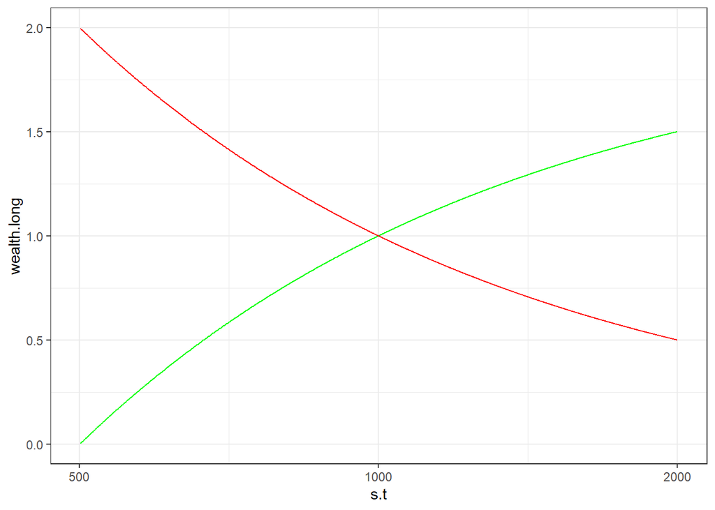

In real world, where everything is purchased with national currencies, your portfolio value is like this:

If you short, your portfolio value should be constant in dollars. If you long, it can go up and down.

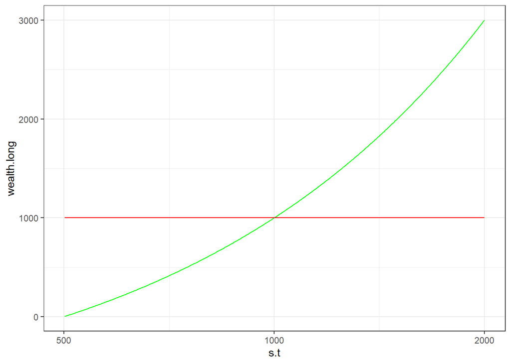

When it comes to leverage, we looked at different levels.

You can get:

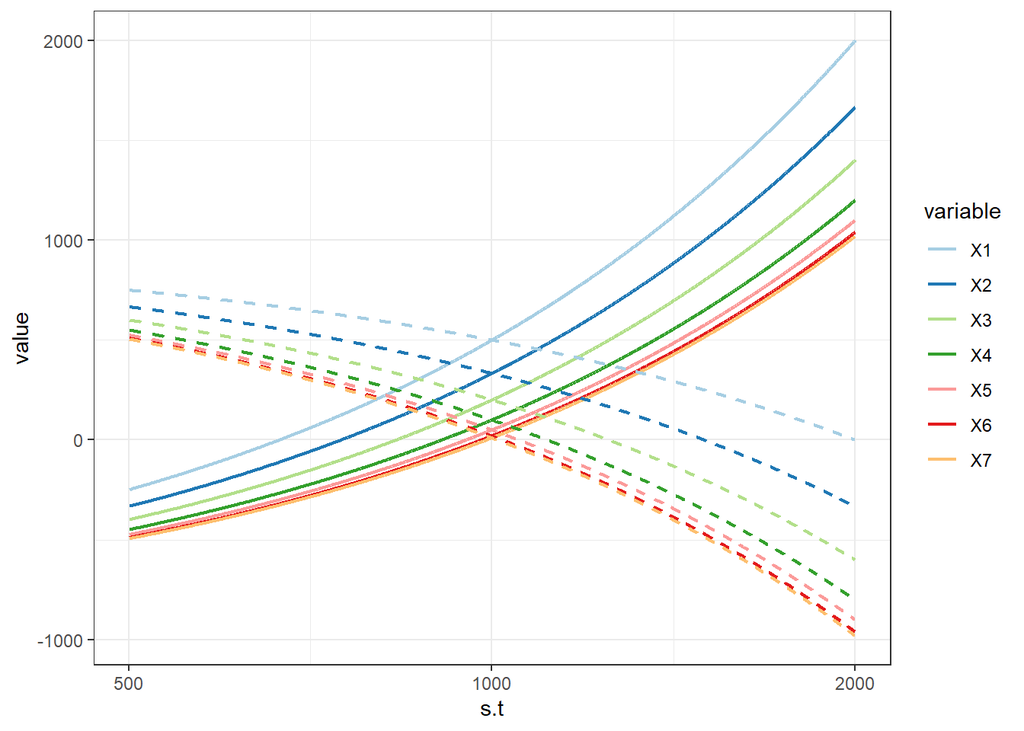

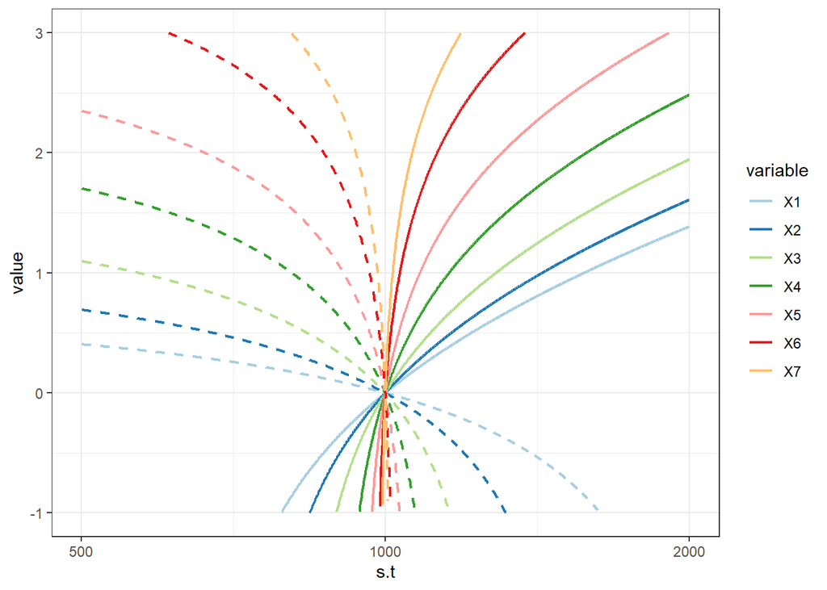

What is the probability that $B_{\mu}(t)$ hits a before b? $P (T_{ab}=T_a ) = \frac{a}{a+b}$

where a, b is the distance from the origin

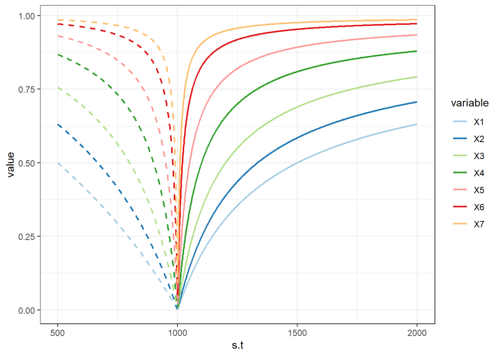

In this section I want to calculate the value of an investment, taking into account the probability of default.

$E[Return] = P(liquidity)*Loss + (1-P(liquidity))*Profit$

Brownian motion with drift: $B_{\mu}(t) = \mu t + \sigma B(t)$

What is the probability that $B_{\mu}(t)$ hits a before b?